# STAT 305 Final Exam Take-Home Problems

Ishaan Sathaye

2025-03-16

# A Property of the Normal Distribution

Recall the following theorem we discussed in **Lecture 10**, which is a fundamental property of the Normal distribution.

> **Theorem (Sum of n independent normal variables):** If $X_1,X_2…,X_n$ are independent random variables, and each $X_i$ follows a normal distribution with mean $𝜇_𝑖$ and standard deviation $𝜎_𝑖$, then the sum $𝑍=𝑋_1+𝑋_2+⋯+𝑋_𝑛$ is also normally distributed.

Proof of this theorem is beyond the scope of STAT 305. However, we may easily verify this theorem with a simulation study. In this problem, your task is to design a simulation study to verify this theorem following the steps below:

- **Simulate 100,000 realizations of random variable** $𝑋_1∼𝑁(𝜇=2,𝜎=1)$ **and store them in a vector, say `x1`.**

  ```r
  # Simulate X1
  set.seed(123)

  x1 <- rnorm(n = 100000, mean = 2, sd = 1)
  head(x1)
  ```

  ```
  ## [1] 1.439524 1.769823 3.558708 2.070508 2.129288 3.715065
  ```

- **Simulate 100,000 realizations of random variable** $𝑋_2∼𝑁(𝜇=3,𝜎=2)$ **and store them in a vector, say `x2`.**

  ```r
  # Simulate X2
  x2 <- rnorm(n = 100000, mean = 3, sd = 2)
  head(x2)
  ```

  ```
  ## [1] 3.529987 6.661495 2.881243 2.893581 3.875808 5.674898
  ```

- **Simulate 100,000 realizations of random variable** $𝑋_3∼𝑁(𝜇=4,𝜎=3)$ **and store them in a vector, say `x3`.**

  ```r
  # Simulate X3
  x3 <- rnorm(n = 100000, mean = 4, sd = 3)
  head(x3)
  ```

  ```
  ## [1]  4.8672403  1.5455891 -0.5698195  2.7133474  1.3379785  3.4567098
  ```

- **Let** $𝑍=𝑋_1+𝑋_2+𝑋_3$**. Then `x1+x2+x3` may be considered as 100,000 realizations of** $𝑍$**.**

  ```r
  # Define Z
  z <- x1 + x2 + x3
  head(z)
  ```

  ```
  ## [1]  9.836752  9.976907  5.870132  7.677437  7.343075 12.846673
  ```

- **Define `z=x1+x2+x3` and create a relative frequency histogram of `z`. You may do this easily by setting `probability=TRUE` inside the `hist()` function.**

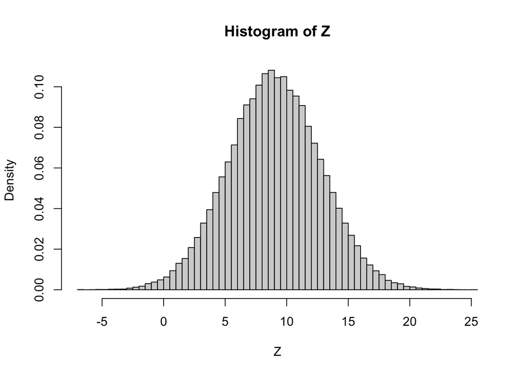

  ```r
  # Histogram with probability = TRUE
  hist(z,
       probability = TRUE,
       breaks = 50,
       main = "Histogram of Z",
       xlab = "Z")
  ```

- **Using the above property of the normal distribution, find the distribution of** $𝑍$**. Add the p.d.f. of this distribution on top of the relative frequency histogram of `z`.**

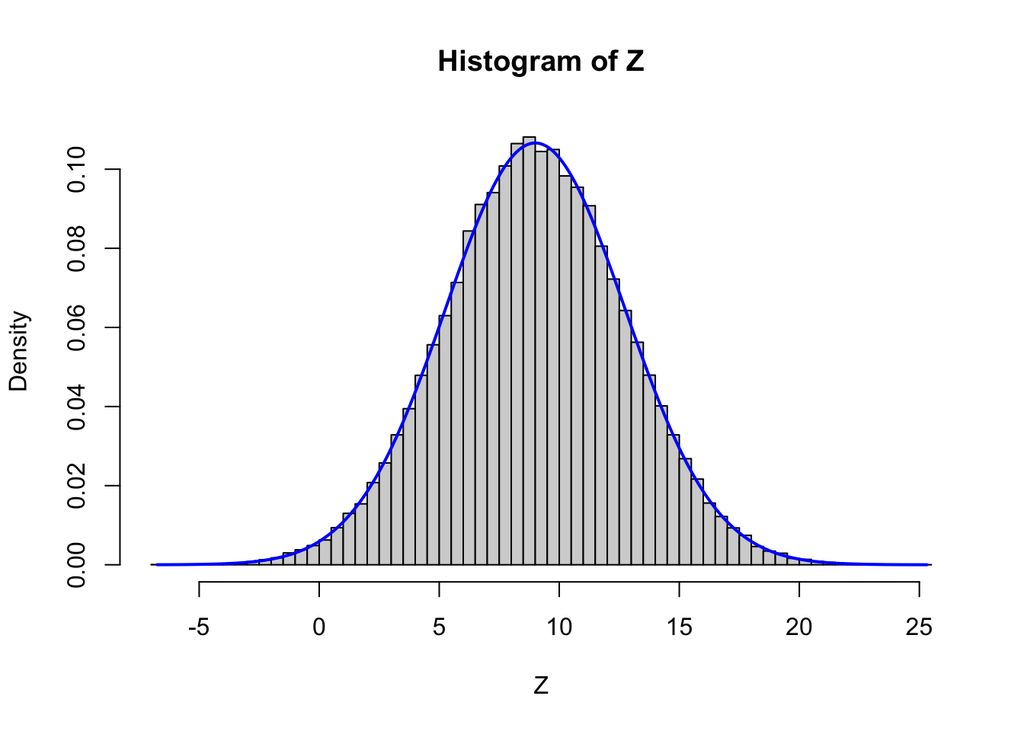

  ```r
  hist(z,
       probability = TRUE,
       breaks = 50,
       main = "Histogram of Z",
       xlab = "Z")

  # Parameters for Z
  mu_Z <- 2 + 3 + 4
  sigma_Z <- sqrt(1^2 + 2^2 + 3^2)

  # X-values covering the range of z
  x_vals <- seq(min(z), max(z), length.out = 1000)

  # Add the theoretical PDF curve
  lines(x_vals,
        dnorm(x_vals, mean = mu_Z, sd = sigma_Z),
        col = "blue",
        lwd = 2)
  ```

- **Does the relative frequency histogram strictly follow the p.d.f.? If so, your simulation study serves as a verification of the above theorem.**
  - Yes, since the histogram matches the superimposed p.d.f. curve.

# Central Limit Theorem

Recall the Central Limit Theorem we discussed in **Lecture 10**, which is a fundamental theorem in probability and statistics.

> **Theorem (Central Limit Theorem)**:
> Let $X_1, X_2, \ldots, X_n$ be a random sample of size $n$ from a distribution with mean $\mu$ and standard deviation $\sigma$. Let
> $$\bar{X} \;=\; \frac{1}{n}\sum_{i=1}^n
> X_i$$
> denote the sample mean. Then, as $n \to \infty$, the distribution of $\bar{X}$ approaches a normal distribution with mean $\mu$ and standard deviation $\frac{\sigma}{\sqrt{n}}$.

Proof of this theorem is beyond the scope of STAT 305. However, we may easily verify this theorem with a simulation study. In this problem, your task is to design a simulation study to verify this theorem following the steps below:

- **Consider an Exponential distribution with rate parameter 0.1.**

  ```r
  # Rate parameter for the Exponential distribution
  lambda <- 0.1
  ```

- **Calculate the mean and standard deviation of this distribution.**

  ```r
  # Mean and standard deviation for the Exponential distribution.
  mean_exp <- 1 / lambda
  sd_exp   <- 1 / lambda

  cat("Exponential Distribution Mean:", mean_exp, "\n")
  ```

  ```
  ## Exponential Distribution Mean: 10
  ```

  ```r
  cat("Exponential Distribution SD:", sd_exp, "\n")
  ```

  ```
  ## Exponential Distribution SD: 10
  ```

- **Generate 100,000 random samples of size** $𝑛=9$ **from this distribution, calculate the mean of each sample, and create the relative frequency histogram of 100,000 sample means.**
- **Ignoring the fact that Central Limit Theorem works for large sample sizes, calculate the sampling distribution of** $\bar{𝑋}$ **using the theorem.**
- **Add the p.d.f. of the sampling distribution you found in the previous step on top of the relative frequency histogram of the sample means you generated. Since the sample size** $𝑛=9$ **is small, we expect a poor match between the relative frequency histogram and the p.d.f. of the sampling distribution. Do you see a poor match?**

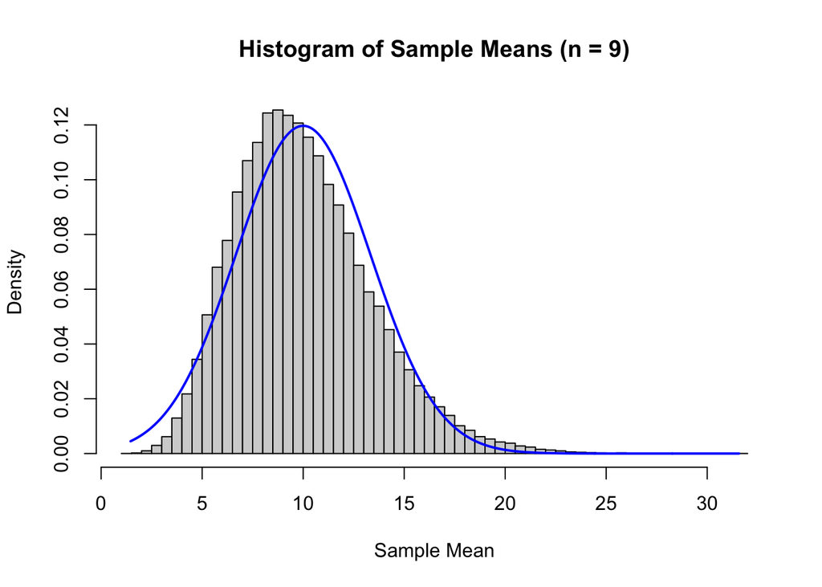

  ```r
  set.seed(123)

  # sample size
  n <- 9
  num_samples <- 100000

  # 100,000 random samples of size 9 and compute the sample means.
  sample_means_n9 <- replicate(num_samples, mean(rexp(n, rate = lambda)))

  # Relative frequency histogram of the sample means
  hist(sample_means_n9, probability = TRUE, breaks = 50,
       main = "Histogram of Sample Means (n = 9)",
       xlab = "Sample Mean", col = "lightgray")


  # Theoretical sampling distribution parameters for n = 9:
  mu   <- mean_exp
  se_n9 <- sd_exp / sqrt(n)


  # Generate x-values spanning the range of the sample means
  x_vals <- seq(min(sample_means_n9), max(sample_means_n9), length.out = 1000)

  # Overlay the theoretical normal pdf on the histogram
  lines(x_vals, dnorm(x_vals, mean = mu, sd = se_n9), col = "blue", lwd = 2)
  ```

  - Yes, I see a poor match.
- **Now repeat everything for 100,000 samples of size** $𝑛=100$ **from the same Exponential distribution. Since the sample size is large, now we expect a good match between the relative frequency histogram and the p.d.f. of the sapling distribution given by the Central Limit Theorem. Do you see a good match?**

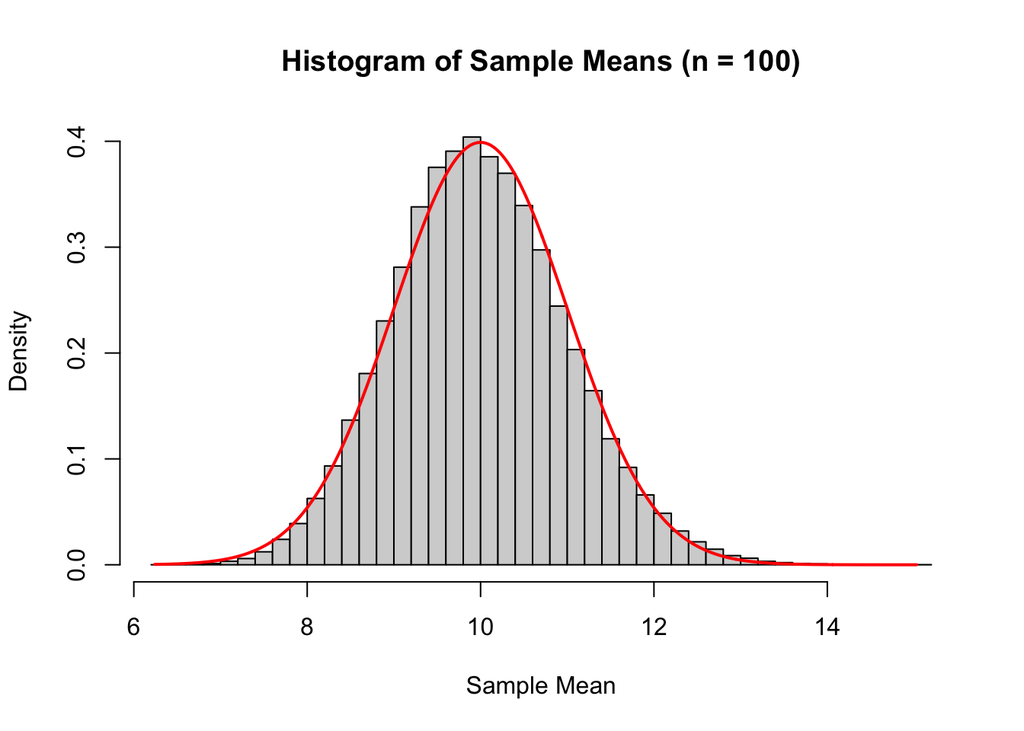

  ```r
  set.seed(123)

  # sample size
  n <- 100

  # 100,000 random samples of size 100 and compute the sample means.
  sample_means_n100 <- replicate(num_samples, mean(rexp(n, rate = lambda)))

  # Relative frequency histogram of the sample means
  hist(sample_means_n100, probability = TRUE, breaks = 50,
       main = "Histogram of Sample Means (n = 100)",
       xlab = "Sample Mean", col = "lightgray")


  # Theoretical sampling distribution parameters for n = 100:
  se_n100 <- sd_exp / sqrt(n)


  # Generate x-values spanning the range of the sample means
  x_vals <- seq(min(sample_means_n100), max(sample_means_n100), length.out = 1000)

  # Overlay the theoretical normal pdf on the histogram
  lines(x_vals, dnorm(x_vals, mean = mu, sd = se_n100), col = "red", lwd = 2)
  ```

  - Yes, I see a good match now.

# **Empirical MSE Comparison for Two Estimators of Variance of a Normal Distribution**

Consider a normal distribution with unknown mean $\mu$ and unknown variance $\sigma^2$. Our task is to estimate the parameter $\sigma^2$. Consider a random sample $X_1, X_2, \ldots, X_n$ from this distribution. In Lecture 11, we considered the following two estimators of $\sigma^2$:

$$\hat{\sigma}^2_1 = \frac{1}{n} \sum_{i=1}^{n} \left( X_i - \bar{X}
\right)^2,$$

$$\hat{\sigma}^2_2 = \frac{1}{n-1} \sum_{i=1}^{n} \left( X_i - \bar{X}
\right)^2.$$

  ```r
  set.seed(123)

  num_sims <- 10000

  true_var <- 10
  true_sd  <- sqrt(10)
  n_values <- 2:50

  # Store empirical MSE for each estimator
  mse1 <- numeric(length(n_values))  # for Estimator 1 (MLE)
  mse2 <- numeric(length(n_values))  # for Estimator 2 (unbiased)
  ```

  ```r
  for (j in seq_along(n_values)) {
    n <- n_values[j]

    # Store each estimate
    est1_vals <- numeric(num_sims)
    est2_vals <- numeric(num_sims)

    # Repeat 10000 times
    for (i in 1:num_sims) {
      # Make a sample of size n from N(50, sqrt(10))
      X <- rnorm(n, mean = 50, sd = true_sd)

      # Get sample mean
      X_bar <- mean(X)

      # Sum of squared deviations
      SS <- sum((X - X_bar)^2)

      # Compute the two estimators
      est1_vals[i] <- SS / n        # Estimator 1 (MLE)
      est2_vals[i] <- SS / (n - 1)  # Estimator 2 (unbiased)
    }

    # Compute empirical MSE for each estimator
    mse1[j] <- mean((est1_vals - true_var)^2)
    mse2[j] <- mean((est2_vals - true_var)^2)
  }

  # Match scale of given graph
  mse1_k <- mse1*100
  mse2_k <- mse2*100
  ```

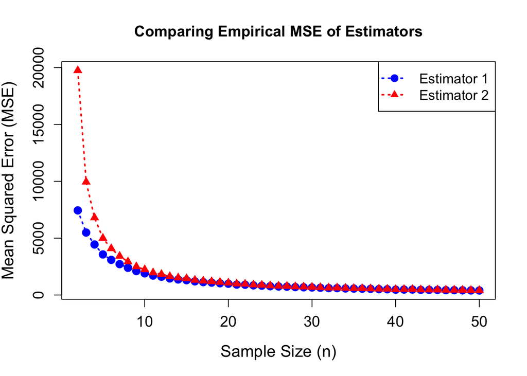

  ```r
  # Plot the MSE of Estimator 1 (MLE)
  plot(n_values, mse1_k,
       type = "o",
       pch = 19, col = "blue",
       lty = 3,
       lwd = 2,
       cex = 1.2,
       cex.lab = 1.3,
       cex.axis = 1.2,
       ylim = range(c(mse1_k, mse2_k)),
       xlab = "Sample Size (n)",
       ylab = "Mean Squared Error (MSE)",
       main = "Comparing Empirical MSE of Estimators")

  # Add the MSE of Estimator 2 (Unbiased)
  lines(n_values, mse2_k,
        type = "o",
        pch = 17, col = "red",
        lty = 3,
        lwd = 2,
        cex = 1.2)

  # Legend
  legend("topright",
         legend = c("Estimator 1", "Estimator 2"),
         col = c("blue", "red"),
         pch = c(19, 17),
         lty = c(3, 3),
         lwd = 2,
         cex = 1.1)
  ```